# Understanding Turkey Higher Education System

PolatAlemd’R’

12/3/2019

# Summary

Welfare of a society is highly correlated with quality of its education system, especially higher education. This study aims to focus on deep-diving on Turkey Higher Education system facts and figures and providing key improvement areas based on findings. The agenda bar on the left-handside will enable reader to navigate across content.

The study consists of three main parts of dataset and structure.

1. University statistics
2. Admission exam facts & figures
3. Exchange program capabilities in country

# Improvement Areas Observed

1. The split of women participated in the program should be close to male split ratio by years.
2. Post-graduate students are mostly studying in Marmara region. More incentives should be given for other regions to obtain better distribution for other regions.
3. Female split in post-graduate is even smaller than total student split. This should be altered.

# Libraries utilized for the study:

```r
library(rvest)
library(dplyr)
library(tidyr)
library(zoo)
library(tidyverse)
library(formattable)
library(ggplot2)
library(lubridate)
library(plyr)
library(readxl)
library(ggpubr)
library(scales)
library(knitr)
```

# 1. University Statistics Analyses

## 1.1. From Raw to Civilized Data

Data is downloaded consisting facts and figures related to universities and students from Council of Higher Education website and is gathered in an excel file.

Names of some cities were written differently in data of different years. To overcome this problem, city named are changed. In example: “ICEL” city names to “MERSIN” and all “AFYON” city names to “AFYONKARAHISAR” and the total number of cities are equal to 81 distinct cities in raw data.

To use it in further analysis, created a *“REGION”* column by grouping the cities.

```r
tmp=tempfile(fileext=".xlsx")
download.file("https://github.com/pjournal/mef03g-polatalemd-r/blob/master/university_statistics_2019-2014.xlsx?raw=true",destfile=tmp,mode='wb')
raw_data=readxl::read_excel(tmp)
file.remove(tmp)
raw_data$city <- revalue(raw_data$city, c("ICEL"="MERSIN"))
raw_data$city <- revalue(raw_data$city, c("AFYON"="AFYONKARAHISAR"))
raw_data <- raw_data %>% mutate(region = case_when(city %in% c("ADANA", "ANTALYA", "BURDUR", "HATAY", "ISPARTA",
                                                       "KAHRAMANMARAS", "MERSIN", "OSMANIYE") ~ "Mediterrenean",
                                           city %in% c("AGRI", "ARDAHAN", "BINGOL", "BITLIS", "ELAZIG",
                                                       "ERZINCAN", "ERZURUM", "HAKKARI", "IGDIR", "KARS",
                                                       "MALATYA", "MUS", "TUNCELI", "VAN") ~ "East Anatolia",
                                           city %in% c("AFYONKARAHISAR", "AYDIN", "DENIZLI", "IZMIR",
                                                       "KUTAHYA", "MANISA", "MUGLA", "USAK") ~ "Aegean",
                                           city %in% c("ADIYAMAN", "BATMAN", "DIYARBAKIR", "GAZIANTEP",
                                                       "MARDIN", "SIIRT", "SANLIURFA", "SIRNAK", "KILIS") ~ "South East Anatolia",
                                           city %in% c("AKSARAY", "ANKARA","CANKIRI","ESKISEHIR","KARAMAN","KAYSERI","KIRIKKALE",
                                                       "KIRSEHIR", "KONYA","NEVSEHIR","NIGDE","SIVAS","YOZGAT") ~ "Middle Anatolia",
                                           city %in% c("BALIKESIR", "BILECIK", "BURSA", "CANAKKALE","EDIRNE",
                                                       "ISTANBUL", "KIRKLARELI","KOCAELI","SAKARYA",
                                                       "TEKIRDAG","YALOVA") ~ "Marmara",
                                           city %in% c("AMASYA","ARTVIN","BARTIN","BAYBURT","BOLU","CORUM",
                                                       "DUZCE","GIRESUN","GUMUSHANE","KARABUK","KASTAMONU",
                                                       "ORDU","RIZE","SAMSUN","SINOP","TOKAT","TRABZON",
                                                       "ZONGULDAK") ~ "Blacksea", TRUE ~ "bilinmiyor"))
```

Understanding variables and observations coming from Council of Higher Education (Yuksek Ogretim Kurumu)

```r
head(raw_data)
```

```
## # A tibble: 6 x 16
##   name_of_univers~ year_of_educati~ type_of_univers~ city  onlisans_male
##   <chr>            <chr>            <chr>            <chr>         <dbl>
## 1 ABANT IZZET BAY~ 2018-2017        DEVLET           BOLU           6230
## 2 ABANT IZZET BAY~ 2017-2016        DEVLET           BOLU           6222
## 3 ABANT IZZET BAY~ 2016-2015        DEVLET           BOLU           5649
## 4 ABANT IZZET BAY~ 2015-2014        DEVLET           BOLU           4269
## 5 ABDULLAH GUL UN~ 2019-2018        DEVLET           KAYS~             0
## 6 ABDULLAH GUL UN~ 2018-2017        DEVLET           KAYS~             0
## # ... with 11 more variables: onlisans_female <dbl>, lisans_male <dbl>,
## #   lisans_female <dbl>, master_male <dbl>, master_female <dbl>,
## #   doctorate_male <dbl>, doctorate_female <dbl>, total_male <dbl>,
## #   total_female <dbl>, total_total <dbl>, region <chr>
```

```r
str(raw_data)
```

```
## Classes 'tbl_df', 'tbl' and 'data.frame':    908 obs. of  16 variables:
##  $ name_of_university: chr  "ABANT IZZET BAYSAL UNIVERSITESI" "ABANT IZZET BAYSAL UNIVERSITESI" "ABANT IZZET BAYSAL UNIVERSITESI" "ABANT IZZET BAYSAL UNIVERSITESI" ...
##  $ year_of_education : chr  "2018-2017" "2017-2016" "2016-2015" "2015-2014" ...
##  $ type_of_university: chr  "DEVLET" "DEVLET" "DEVLET" "DEVLET" ...
##  $ city              : chr  "BOLU" "BOLU" "BOLU" "BOLU" ...
##  $ onlisans_male     : num  6230 6222 5649 4269 0 ...
##  $ onlisans_female   : num  3521 3309 2969 2197 0 ...
##  $ lisans_male       : num  7970 7243 6633 6149 854 ...
##  $ lisans_female     : num  11171 10570 10097 9604 377 ...
##  $ master_male       : num  1333 1367 1280 936 46 ...
##  $ master_female     : num  1204 1166 1098 845 40 ...
##  $ doctorate_male    : num  230 199 192 155 50 43 32 25 17 18 ...
##  $ doctorate_female  : num  204 165 153 115 41 36 21 9 5 88 ...
##  $ total_male        : num  15763 15031 13754 11509 950 ...
##  $ total_female      : num  16100 15210 14317 12761 458 ...
##  $ total_total       : num  31863 30241 28071 24270 1408 ...
##  $ region            : chr  "Blacksea" "Blacksea" "Blacksea" "Blacksea" ...
```

## 1.2. Analyses of Student Numbers Dataset

### 1.2.1. Number of Student in All Universities

This table enables to observe total number of students (7M) by type of university in the last five years.

Data is grouped by ‘year_of_education’ column and calculated the total number of students at State and foundation University.The increase in the number of population has led to an increase in the number of students in both state and foundation universities. However, observing that the growth rates are decreasing.

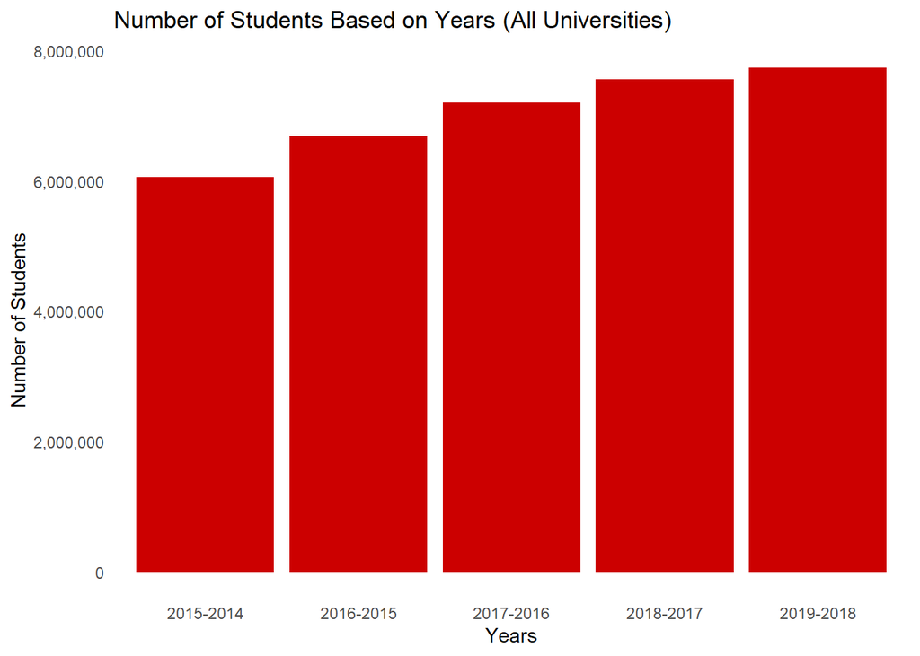

```r
devlet_total <- raw_data %>%
  transmute(year_of_education, type_of_university, total_total) %>%
  group_by(year_of_education) %>%
  transmute(total_student_number_d = sum(total_total)) %>%
  distinct() %>%
  arrange(desc(total_student_number_d))
plot1 <- ggplot(devlet_total, aes(x=year_of_education, y=total_student_number_d)) +
  geom_bar(stat="identity",position="dodge", fill = "#CC0000") +scale_y_continuous(labels = scales::comma)+
  labs(x="Years", y = "Number of Students")+labs(title = "Number of Students Based on Years (All Universities)") + theme_minimal() + theme(line=element_blank())
plot1
```

### 1.2.1. Number of Student in State Universities

This table enables to observe total number of students (7M) by type of university in the last five years.

Data is grouped by ‘year_of_education’ column and calculated the total number of students at State and foundation University.The increase in the number of population has led to an increase in the number of students in both state and foundation universities. However, observing that the growth rates are decreasing.

State universities have 7134674 students in total (Academic year of 2018-2019)

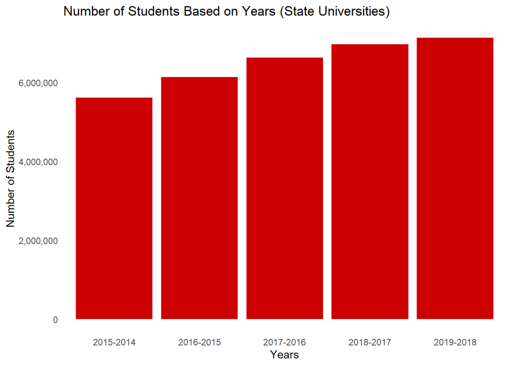

```r
devlet_total <- raw_data %>%
  transmute(year_of_education, type_of_university, total_total) %>%
  filter(type_of_university == 'DEVLET') %>%
  group_by(year_of_education) %>%
  transmute(total_student_number_d = sum(total_total)) %>%
  distinct() %>%
  arrange(desc(total_student_number_d))
plot1 <- ggplot(devlet_total, aes(x=year_of_education, y=total_student_number_d)) +
  geom_bar(stat="identity",position="dodge", fill = "#CC0000") +scale_y_continuous(labels = scales::comma)+
  labs(x="Years", y = "Number of Students")+labs(title = "Number of Students Based on Years (State Universities)") + theme_minimal() + theme(line=element_blank())
plot1
```

### 1.2.2. Number of Students in Foundation Universities

Data is grouped by ‘year_of_education’ column and calculated the total number of students at State and foundation University.The increase in the number of population has led to an increase in the number of students in both state and foundation universities. However, observing that the growth rates are decreasing.

Foundation universities have 595116 students in total (Academic year of 2018-2019)

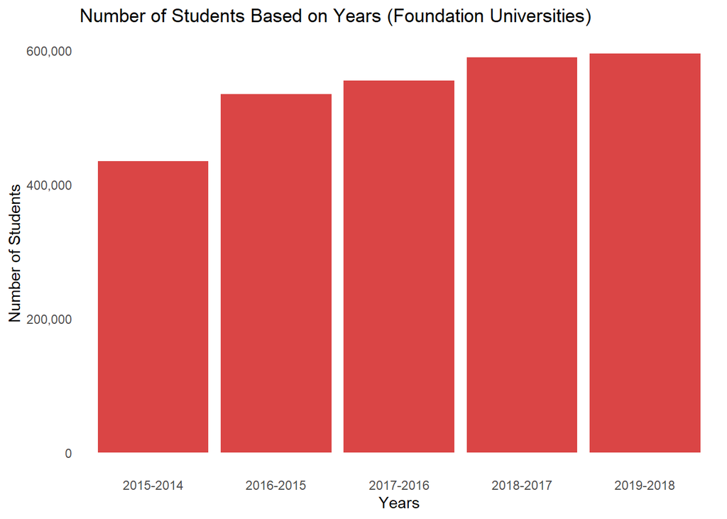

```r
vakif_total <- raw_data %>%
  transmute(year_of_education, type_of_university, total_total) %>%
  filter(type_of_university == 'VAKIF') %>%
  group_by(year_of_education) %>%
  transmute(total_student_number_v = sum(total_total)) %>%
  distinct() %>%
  arrange(desc(total_student_number_v))
plot2 <- ggplot(vakif_total, aes(x=year_of_education, y=total_student_number_v)) +
  geom_bar(stat="identity",position="dodge",fill = "#DA4545") +scale_y_continuous(labels = scales::comma)+
  labs(x="Years", y = "Number of Students")+labs(title = "Number of Students Based on Years (Foundation Universities)") + theme_minimal() + theme(line=element_blank())
plot2
```

You can see the difference in the number of students in state and foundation universities in the chart below.

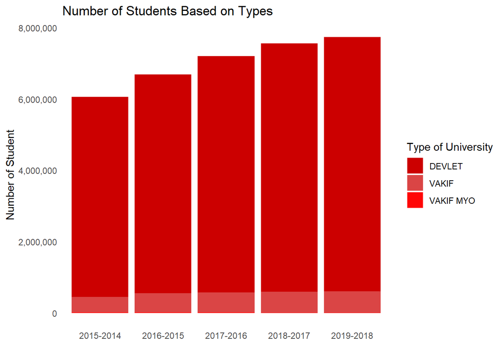

```r
a <- raw_data %>%
  transmute(year_of_education, type_of_university, total_total) %>%
  group_by(type_of_university) %>%
  transmute(year_of_education,total_total,sum_total = sum(total_total)) %>% ungroup() %>%
  group_by(year_of_education,type_of_university) %>%
  transmute(total_student_number= sum(total_total)) %>%
  distinct() %>%
  arrange(desc(total_student_number)) %>% distinct()
plot_a <- ggplot(a,aes(x = year_of_education, y = total_student_number,fill = type_of_university))+
  geom_bar(stat="identity",position="stack") +scale_fill_manual(values = c("#CC0000","#DA4545","#FF0606"))+
  scale_y_continuous(labels = scales::comma)+
  labs(x="", y = "Number of Student")+
  labs(title = "Number of Students Based on Types",fill="Type of University") + theme_minimal() + theme(line=element_blank())
plot_a
```

### 1.2.2. Number of University in Turkey

To understand better the landscape of the higher education ecosystem in Turkey, analyzing growth and distribution of state and foundation type of universities are essential. Observing that most 64% of universities are state universities. However, 92% of total students are studying in state universities. This uneven distribution is caused by open university service. Although the increase in the number of universities is normal due to the increase in population, we observe a decrease in foundation universities in 2016-2017 period.We can say that is the result of coup attempt on July 15, 2016.With the closure of foundation universities, students were placed in state universities.This has led to an increase in the number of students in state universities on 2017-2018.

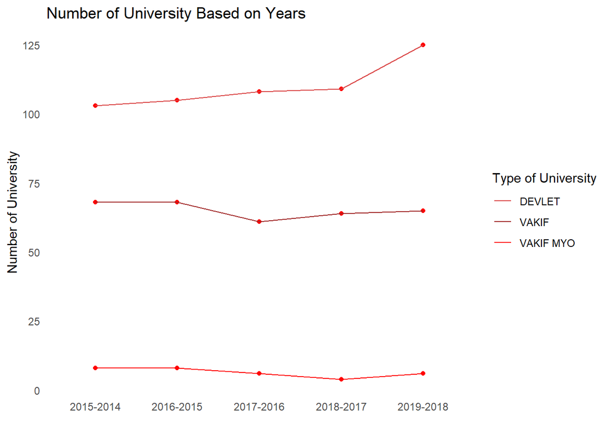

```r
n <- rep(1, times= nrow(raw_data))
uni_numbers_each_year <- raw_data %>%
  mutate(number1=n) %>%
  select(year_of_education, type_of_university, total_total, name_of_university, number1) %>%
  group_by(year_of_education,type_of_university) %>%
  transmute( number_of_uni=sum(number1))%>% distinct()
plot1b <- ggplot(uni_numbers_each_year,aes(x = year_of_education, y = number_of_uni,color=type_of_university))+
  geom_point(shape = 21,color = "red",fill="red")+
  geom_line(aes(group = type_of_university)) +
  scale_color_manual(values=c("#DA4545","#A12727","#FF0606"))+
  labs(x="", y = "Number of University",color = "Type of University")+
  labs(title = "Number of University Based on Years") + theme_minimal() + theme(line=element_blank())
plot1b
```

### 1.2.3. Growth Rates of Number of Students

```r
total <- raw_data %>%
  transmute(year_of_education, total_total) %>%
  group_by(year_of_education) %>%
  transmute(total_student_number_d = sum(total_total)) %>%
  distinct() %>%
  arrange(desc(total_student_number_d))
total_growth_x <- total
total_growth_x["Growth1"] <- NA
total_growth_x$Growth1 <- c((total_growth_x$total_student_number_d[1]-total_growth_x$total_student_number_d[2])/total_growth_x$total_student_number_d[1],
                           (total_growth_x$total_student_number_d[2]-total_growth_x$total_student_number_d[3])/total_growth_x$total_student_number_d[2],
                           (total_growth_x$total_student_number_d[3]-total_growth_x$total_student_number_d[4])/total_growth_x$total_student_number_d[3],
                           (total_growth_x$total_student_number_d[4]-total_growth_x$total_student_number_d[5])/total_growth_x$total_student_number_d[4],0)
total_growth_x <- total_growth_x %>% mutate(percent1 =paste0(round(Growth1*100, 2), "%"))
total_growth_x <-total_growth_x %>% filter(Growth1 != 0)
total_growth_x
```

```
## # A tibble: 4 x 4
## # Groups:   year_of_education [4]
##   year_of_education total_student_number_d Growth1 percent1
##   <chr>                              <dbl>   <dbl> <chr>
## 1 2019-2018                        7740502  0.0233 2.33%
## 2 2018-2017                        7560371  0.0478 4.78%
## 3 2017-2016                        7198987  0.0708 7.08%
## 4 2016-2015                        6689185  0.0936 9.36%
```

You can see growth rate in State university.

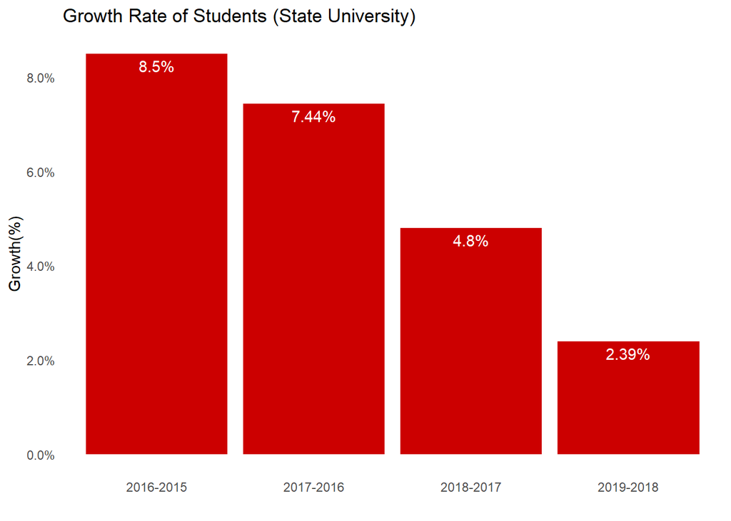

```r
total_growth1 <- devlet_total
total_growth1["Growth1"] <- NA
total_growth1$Growth1 <- c((total_growth1$total_student_number_d[1]-total_growth1$total_student_number_d[2])/total_growth1$total_student_number_d[1],
                         (total_growth1$total_student_number_d[2]-total_growth1$total_student_number_d[3])/total_growth1$total_student_number_d[2],
                         (total_growth1$total_student_number_d[3]-total_growth1$total_student_number_d[4])/total_growth1$total_student_number_d[3],
                         (total_growth1$total_student_number_d[4]-total_growth1$total_student_number_d[5])/total_growth1$total_student_number_d[4],0)
total_growth1 <- total_growth1 %>% mutate(percent1 =paste0(round(Growth1*100, 2), "%"))
total_growth1 <-total_growth1 %>% filter(Growth1 != 0)
total_growth2 <- vakif_total
plot3 <- ggplot(total_growth1, aes(x = year_of_education, y = Growth1)) +
  geom_bar(stat = "identity", position = "dodge", fill = "#CC0000") +
  geom_text(aes(label = percent1), position = position_dodge(0.9),
            vjust = 1.5, color = "white")+
  scale_y_continuous(labels = scales::percent) +
  labs(x = "", y = "Growth(%)")  +
  labs(title = "Growth Rate of Students (State University)")+ theme_minimal()+ theme(line=element_blank())
plot3
```

You can see growth rate in foundation university.

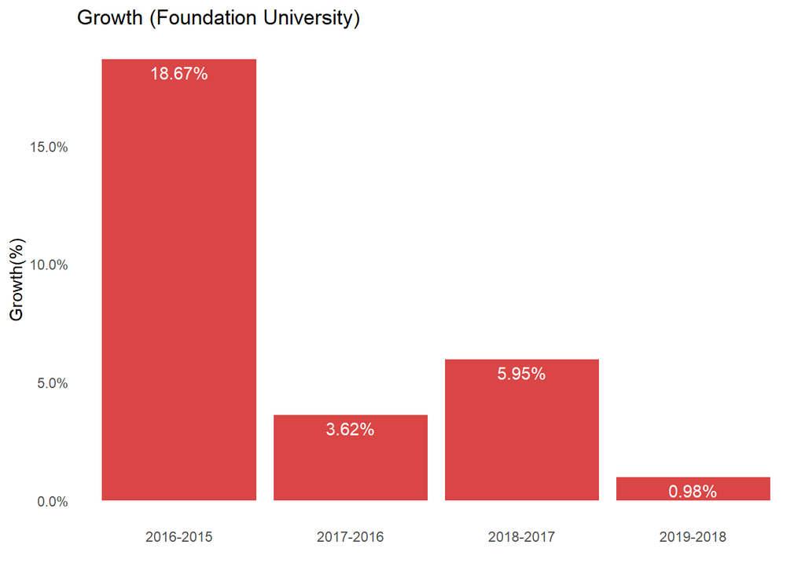

```r
total_growth2 <- vakif_total
total_growth2["Growth2"] <- NA
total_growth2$Growth2 <- c((total_growth2$total_student_number_v[1]-total_growth2$total_student_number_v[2])/total_growth2$total_student_number_v[1],
                           (total_growth2$total_student_number_v[2]-total_growth2$total_student_number_v[3])/total_growth2$total_student_number_v[2],
                           (total_growth2$total_student_number_v[3]-total_growth2$total_student_number_v[4])/total_growth2$total_student_number_v[3],
                           (total_growth2$total_student_number_v[4]-total_growth2$total_student_number_v[5])/total_growth2$total_student_number_v[4],0)
total_growth2 <- total_growth2 %>% mutate(percent2 =paste0(round(Growth2*100, 2), "%"))
total_growth2 <-total_growth2 %>% filter(Growth2 != 0)
plot4 <-ggplot(total_growth2, aes(x = year_of_education, y = Growth2)) +
  geom_bar(stat = "identity", position = "dodge", fill = "#DA4545") +
  geom_text(aes(label = percent2), position = position_dodge(0.9),
            vjust = 1.5, color = "white")+
  scale_y_continuous(labels = scales::percent) +
  labs(x = "", y = "Growth(%)")+
  labs(title = "Growth (Foundation University)")+ theme_minimal()+ theme(line=element_blank())
plot4
```

### 1.2.4. Gender Distribution of University Students

The following table demonstrated the gender distribution of university students. To obtain, data was edited and converted gender names into columns. Percentage of females in higher education is 47.5 for 2018-2019 Academic Year. The average of last five years’ female split is 46.4%. This showcases an improvement where has an improvement area.

Although the number of female students increases every year, the number of male students is still leading. One improvement area is to encourage female participation to higher education to have country representative education outcome.

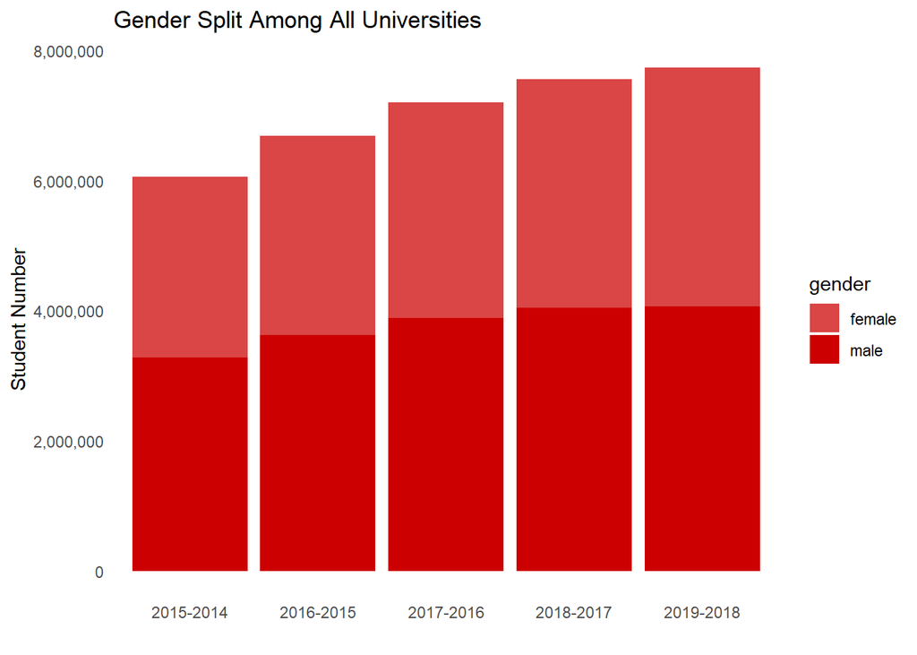

```r
Gender <- raw_data %>%
  transmute(year_of_education,name_of_university, female=total_female, male=total_male) %>%
  gather(gender,student_num,female:male)
plot6 <-ggplot(data = Gender, aes(x = year_of_education, y = student_num, fill = gender)) +
  geom_bar(stat = "identity",position = "stack") + scale_y_continuous(labels = scales::comma) +
  labs(x = "", y = "Student Number", title = "Gender Split Among All Universities") + scale_fill_manual(values = c("#DA4545", "#CC0000"))+ theme_minimal()+ theme(line=element_blank())
plot6
```

### 1.2.5. Student Numbers in Universities

Anadolu University has the highest student population since it has a unique program called “Open Education” which enables students to participate with distance. For the last 5 years, Anadolu University has been able to provide education to 15 million students.

```r
university <- raw_data%>%
  select(name_of_university, total_total)%>%
  group_by(name_of_university)%>%
  transmute(lala = sum(total_total)) %>% distinct() %>%
  arrange(desc(lala)) %>%
  filter(row_number()<2)
print(university)
```

[output not shown]

### 1.2.6. Differentiation of Associate Program

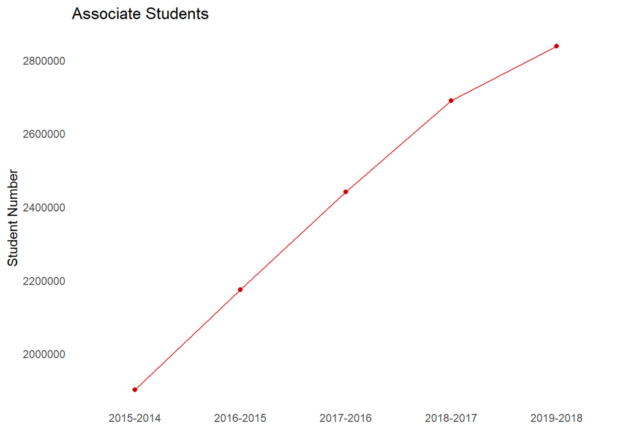

```r
raw_data%>%
  select(onlisans_male, onlisans_female, year_of_education)%>%
  group_by(year_of_education)%>%
  transmute(onlisans_total = sum(onlisans_female,onlisans_female)) %>% distinct() %>%
  arrange(desc(onlisans_total)) %>%
  print(onlisans_total) %>%
  ggplot(., aes(x = year_of_education, y = onlisans_total, group=1)) +
  geom_line(color="#DA4545") +
  geom_point(color= "#CC0000")+
  labs( x="" , y = "Student Number", title="Associate Students")+
  theme_minimal()+ theme(line=element_blank())
```

### 1.2.7. Differentiation of Bachelors Program

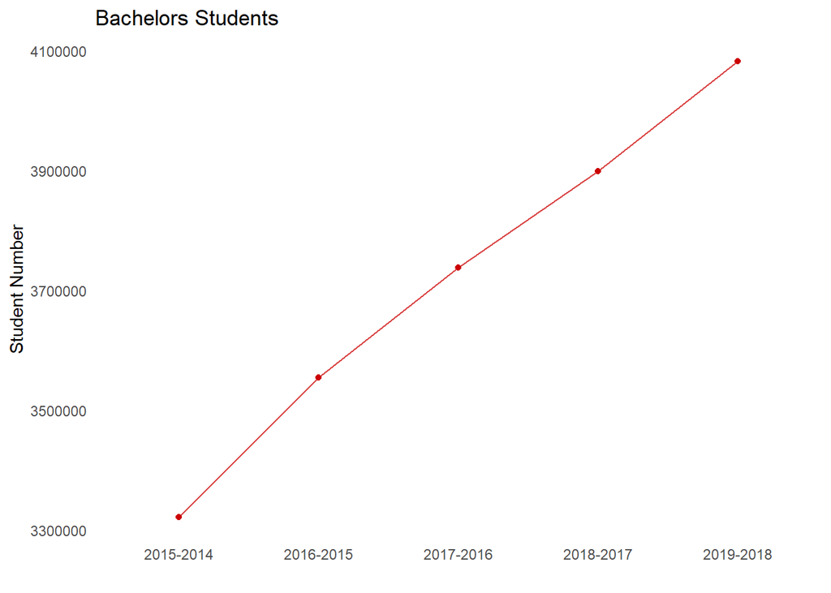

```r
raw_data%>%
  select(lisans_male, lisans_female, year_of_education)%>%
  group_by(year_of_education)%>%
  transmute(lisans_total = sum(lisans_female,lisans_female)) %>% distinct() %>%
  arrange(desc(lisans_total)) %>%
  print(lisans_total) %>%
  ggplot(., aes(x = year_of_education, y = lisans_total, group=1)) +
  geom_line(color="#DA4545") +
  geom_point(color= "#CC0000")+
   labs( x="" , y = "Student Number", title="Bachelors Students")+
  theme_minimal()+ theme(line=element_blank())
```

### 1.2.8. Differentiation of Masters Program

The number of students enrolled to masters program is decresing. This is because, after 2016 year attempted coup, 6 numbers of foundation universities linked to FETÖ has been closed and Master’s students are not transferred to other universities. The decreasing trend continuous. This consits of 5% percentage of total students with absolut number of 1693724 students.

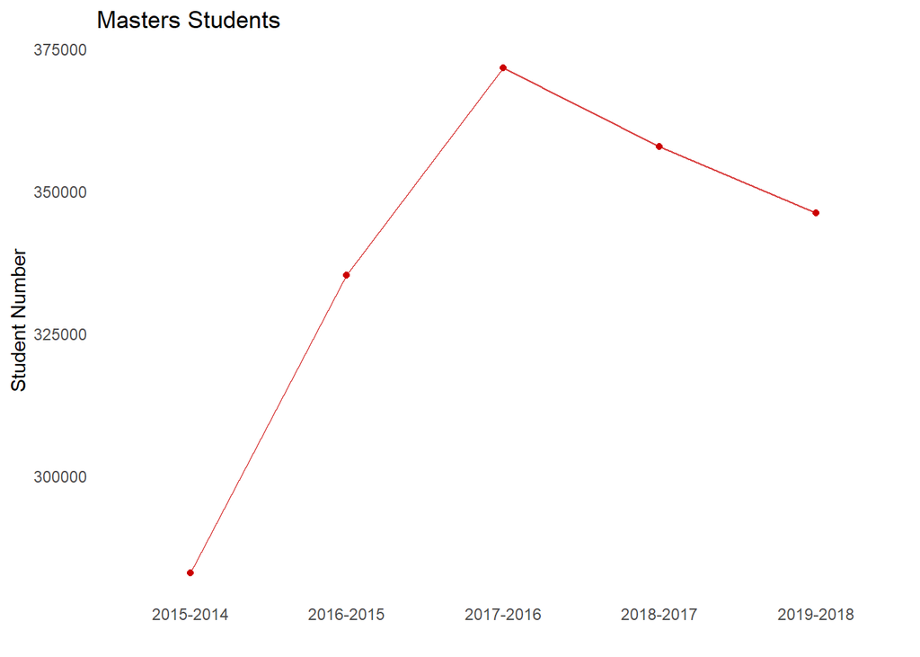

```r
raw_data%>%
  select(master_male, master_female, year_of_education)%>%
  group_by(year_of_education)%>%
  transmute(master_total = sum(master_female,master_female)) %>% distinct() %>%
  arrange(desc(master_total)) %>%
  print(master_total) %>%
  ggplot(., aes(x = year_of_education, y = master_total, group=1)) +
  geom_line(color="#DA4545") +
  geom_point(color= "#CC0000")+
   labs( x="" , y = "Student Number", title="Masters Students")+
  theme_minimal()+ theme(line=element_blank())
```

### 1.2.9. Differentiation of Doctorate Program

The number of students in doctorate program is increasing. This number is not impacted from close-out of foundation universities event since doctorate students can continue their program with different scholars. The second reason is because this number is the smallest fraction in total higher education. The doctorate students consists of 1% percent of total student number with absolute number of 378444.

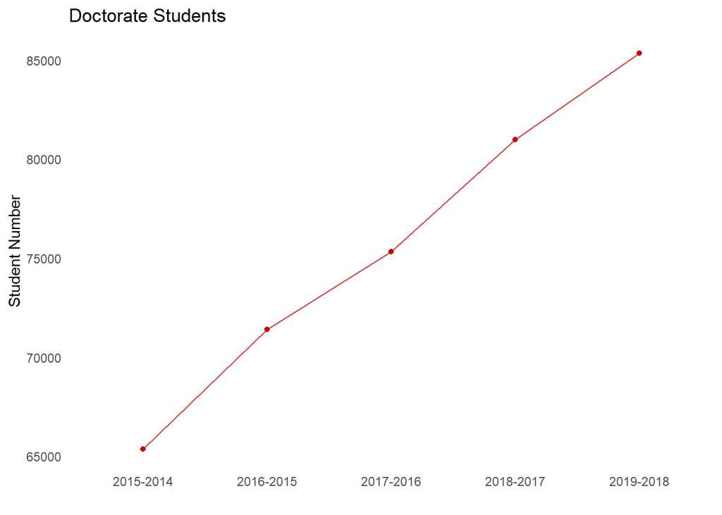

```r
raw_data%>%
  select(doctorate_male, doctorate_female, year_of_education)%>%
  group_by(year_of_education)%>%
  transmute(doctorate_total = sum(doctorate_female,doctorate_female)) %>% distinct() %>%
  arrange(desc(doctorate_total)) %>%
  print(doctorate_total) %>%
  ggplot(., aes(x = year_of_education, y = doctorate_total, group=1)) +
  geom_line(color="#DA4545") +
  geom_point(color= "#CC0000")+
  labs( x="" , y = "Student Number", title="Doctorate Students")+
  theme_minimal()+ theme(line=element_blank())
```